# Final Exam - Estimating Views

Vishal Gupta

5/1/2019

```r
library(dplyr)
library(tidyr)
library(randomForest)
library(rpart)
library(rpart.plot)
library(caret)
library(e1071)
```

#### Problem 1 - Exploratory Data Analysis

Load youtube_train.csv into a data frame called train.

```r
yt_train = read.csv("~/Downloads/youtube_train.csv")
yt_test = read.csv("~/Downloads/youtube_test.csv")
```

How many rows are in the training dataset?

```r
yt_train %>% nrow()
```

```
## [1] 30002
```

What is the average amount of likes per video in the training dataset?

```r
yt_train %>% summarise(ct = mean(likes))
```

```
##         ct
## 1 75461.28
```

What is the category of the video with most views in the training set?

```r
yt_train %>% group_by(category) %>% summarise(ct = sum(as.numeric(views))) %>% arrange(desc(ct))
```

```
## # A tibble: 16 x 2
##    category                       ct
##    <fct>                       <dbl>
##  1 Music                 29638436469
##  2 Entertainment         14983251896
##  3 Film & Animation       5593971711
##  4 Comedy                 3884145104
##  5 People & Blogs         3445319361
##  6 Sports                 3215887903
##  7 Howto & Style          3043833827
##  8 Science & Technology   2353004452
##  9 Gaming                 1695806565
## 10 News & Politics         951247002
## 11 Education               897973625
## 12 Pets & Animals          571507414
## 13 Autos & Vehicles        408916517
## 14 Travel & Events         255908375
## 15 Nonprofits & Activism    89373025
## 16 Shows                    37707034
```

- **Music**
- Sports
- Comedy
- Entertainment
- Shows
- Film and Animation

Which category has the least amount of dislikes in the training set?

```r
yt_train %>% group_by(category) %>% summarise(ct = sum(dislikes)) %>% arrange(ct)
```

```
## # A tibble: 16 x 2
##    category                    ct
##    <fct>                    <int>
##  1 Shows                    18170
##  2 Autos & Vehicles        183136
##  3 Travel & Events         265473
##  4 Pets & Animals          400006
##  5 Education              1036279
##  6 Nonprofits & Activism  1724835
##  7 Science & Technology   2881615
##  8 News & Politics        3067166
##  9 Sports                 3912650
## 10 Howto & Style          4062165
## 11 Film & Animation       4666535
## 12 Comedy                 5409956
## 13 Gaming                 7199360
## 14 People & Blogs         7315704
## 15 Entertainment         34023212
## 16 Music                 38046316
```

- Education
- Pets and Animals
- **Shows**
- People and Blogs
- Comedy
- Science and Technology
- Sports

In the training set, out of the videos with at least 1 million likes, how many have at least 100,000 comments?

```r
yt_train %>% filter(likes>=1000000) %>% filter(comment_count>=100000) %>% nrow()
```

```
## [1] 184
```

#### Problem 2.1 - Simple Linear Regression

For the rest of this problem, we will be working with log(views), log(likes), log(dislikes), and log(comment_count), which helps us manage the outliers with excessively large amounts of views, likes, dislikes, and comments. The values of log(views), log(likes), log(dislikes), and log(comment_count) are found in the columns logviews, loglikes, logdislikes and logcomments, respectively.

What is the value of log(views) that our baseline model predicts?

```r
mean(log(yt_train$views))
```

```
## [1] 13.37152
```

What is the correlation between log(views) and log(dislikes) in the training set?

```r
cor(log(yt_train$views),log(yt_train$dislikes))
```

```
## [1] 0.8722925
```

Choose the most reasonable answer from the following statements:

- Higher log of dislikes are associeted with higher log of views, likely because the popular videos often have many dislikes.
- High log of dislikes are associated with less log of views.
- There is no association between log of dislikes and log of views.

#### Problem 2.2 - Simple Linear Regression (cont’d)

Load youtube_test.csv into a data frame called test. Create a linear model that predicts log(views) using log(dislikes).

```r
yt_model = lm(logviews ~ logdislikes,data = yt_train)
```

What is the coefficient of log(dislikes)?

```r
summary(yt_model)
```

```
##
## Call:
## lm(formula = logviews ~ logdislikes, data = yt_train)
##
## Residuals:
##     Min      1Q  Median      3Q     Max
## -4.1050 -0.4542  0.0600  0.5057  4.6775
##
## Coefficients:
##             Estimate Std. Error t value Pr(>|t|)
## (Intercept) 8.305149   0.017056   486.9   <2e-16 ***
## logdislikes 0.786930   0.002547   309.0   <2e-16 ***
## ---
## Signif. codes:  0 '***' 0.001 '**' 0.01 '*' 0.05 '.' 0.1 ' ' 1
##
## Residual standard error: 0.8129 on 30000 degrees of freedom
## Multiple R-squared:  0.7609, Adjusted R-squared:  0.7609
## F-statistic: 9.547e+04 on 1 and 30000 DF,  p-value: < 2.2e-16
```

What is the R2 on the test set?

```r
y_pred = predict(yt_model,yt_test,type = 'response')
y_true = yt_test$logviews
rss = sum((y_pred - y_true) ^ 2)
tss = sum((y_true - mean(y_true)) ^ 2)
1 - rss/tss
```

```
## [1] 0.7519245
```

#### Problem 3 - Adding More Variables

As good practice, it is always helpful to first check for multicollinearity before running larger models.

Examine the correlation between the following variables:

logdislikes, loglikes, logcomments, tags, publish_month, and trending_month

```r
cor(yt_train$loglikes,yt_train$logdislikes)
```

```
## [1] 0.8155788
```

```r
cor(yt_train$logcomments,yt_train$logdislikes)
```

```
## [1] 0.8722994
```

```r
cor(yt_train$tags,yt_train$logcomments)
```

```
## [1] 0.07269055
```

```r
cor(yt_train$trending_month,yt_train$tags)
```

```
## [1] -0.02377686
```

```r
cor(yt_train$publish_month,yt_train$trending_month)
```

```
## [1] 0.8993611
```

```r
cor(yt_train$logcomments,yt_train$loglikes)
```

```
## [1] 0.9030509
```

Which of the following pairs of variables have correlation with magnitude above 0.8? Select all that apply.

- **logdislikes**, **loglikes**
- **logcomments**, **logdislikes**
- tags, logcomments
- trending_month, tags
- **publish_month, trending_month**
- **logcomments, loglikes**

Create a linear model that predicts log(views) using the following variables:

logdislikes, tags, and trending_month.

```r
yt_model_2 = lm(logviews ~ logdislikes + tags + trending_month,data = yt_train)
```

We have excluded loglikes, logcomments, and publish_month due to concerns about multicollinearity.

What is the value of the intercept?

```r
summary(yt_model_2)
```

```
##
## Call:
## lm(formula = logviews ~ logdislikes + tags + trending_month,
##     data = yt_train)
##
## Residuals:
##     Min      1Q  Median      3Q     Max
## -4.0483 -0.4588  0.0560  0.5049  4.7016
##
## Coefficients:
##                  Estimate Std. Error t value Pr(>|t|)
## (Intercept)     8.361e+00  1.972e-02  424.00  < 2e-16 ***
## logdislikes     7.834e-01  2.558e-03  306.25  < 2e-16 ***
## tags            1.655e-04  3.177e-05    5.21  1.9e-07 ***
## trending_month -1.409e-02  1.232e-03  -11.44  < 2e-16 ***
## ---
## Signif. codes:  0 '***' 0.001 '**' 0.01 '*' 0.05 '.' 0.1 ' ' 1
##
## Residual standard error: 0.8108 on 29998 degrees of freedom
## Multiple R-squared:  0.7622, Adjusted R-squared:  0.7621
## F-statistic: 3.204e+04 on 3 and 29998 DF,  p-value: < 2.2e-16
```

What is the R2 on the test set?

```r
y_pred = predict(yt_model_2,yt_test,type = 'response')
y_true = yt_test$logviews
rss = sum((y_pred - y_true) ^ 2)
tss = sum((y_true - mean(y_true)) ^ 2)
1 - rss/tss
```

```
## [1] 0.7529759
```

#### Problem 4 - Interpreting Linear Regression

Using the model from Problem 3, which of the following variables are significant at a level of 0.001 (p-value below 0.001)? Select all that apply.

```r
summary(yt_model_2)
```

```
##
## Call:
## lm(formula = logviews ~ logdislikes + tags + trending_month,
##     data = yt_train)
##
## Residuals:
##     Min      1Q  Median      3Q     Max
## -4.0483 -0.4588  0.0560  0.5049  4.7016
##
## Coefficients:
##                  Estimate Std. Error t value Pr(>|t|)
## (Intercept)     8.361e+00  1.972e-02  424.00  < 2e-16 ***
## logdislikes     7.834e-01  2.558e-03  306.25  < 2e-16 ***
## tags            1.655e-04  3.177e-05    5.21  1.9e-07 ***
## trending_month -1.409e-02  1.232e-03  -11.44  < 2e-16 ***
## ---
## Signif. codes:  0 '***' 0.001 '**' 0.01 '*' 0.05 '.' 0.1 ' ' 1
##
## Residual standard error: 0.8108 on 29998 degrees of freedom
## Multiple R-squared:  0.7622, Adjusted R-squared:  0.7621
## F-statistic: 3.204e+04 on 3 and 29998 DF,  p-value: < 2.2e-16
```

- **logdislikes**
- loglikes
- **tags**
- logviews
- **trending_month**

Using the model from Problem 3, how would you interpret the coefficient of tags?

- **All else being equal, an increase in tags is associated with a 1.655e-04 increase in log(views).**
- All else being equal, an increase in tags is associated with a 1.655e-04 decrease in log(views).

Using the simple model from Problem 2, if the amount of dislikes is 1000, how many views does the model predict the video has?

- 795.2351
- 3182852
- 1906.064
- **928263.8**

#### Problem 5 - CART and Random Forest

```r
yt_model_cart = rpart(logviews ~ logdislikes,yt_train, cp=0.05)
```

Looking at the plot of the tree, how many different predicted values are there?

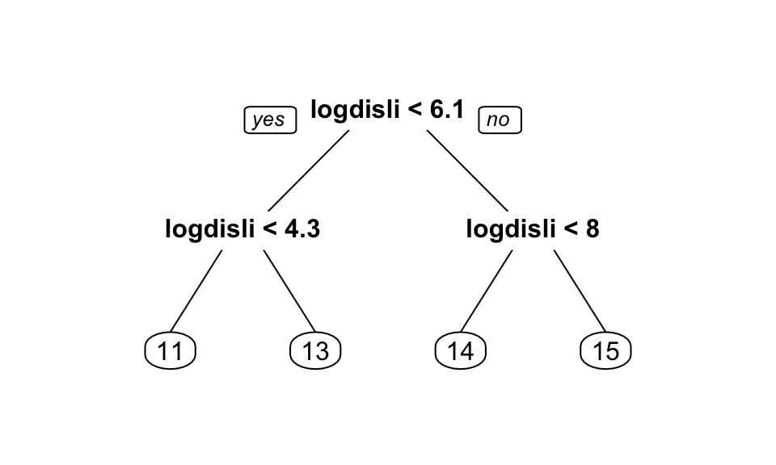

```r
prp(yt_model_cart)
```

What is the R2 of this model on the test set?

```r
y_pred = predict(yt_model_cart,yt_test)
y_true = yt_test$logviews
rss = sum((y_pred - y_true) ^ 2)
tss = sum((y_true - mean(y_true)) ^ 2)
1 - rss/tss
```

```
## [1] 0.6569652
```

The out-of-sample R2 does not appear to be very good under regression trees, compared to a linear regression model. We could potentially improve it via cross validation.

Set seed to 100, run a 10-fold cross-validated cart model, with cp ranging from 0.0001 to 0.005 in increments of 0.0001. What is the optimal cp value on this grid?

```r
set.seed(100)
numFolds = trainControl(method = "cv", number = 10 )
cartGrid = expand.grid( .cp = seq(0.0001,0.005,0.0001))
train(logviews ~ logdislikes, data = yt_train, method = "rpart", trControl = numFolds, tuneGrid = cartGrid )
```

```
## CART
##
## 30002 samples
##     1 predictor
##
## No pre-processing
## Resampling: Cross-Validated (10 fold)
## Summary of sample sizes: 27002, 27002, 27002, 27002, 27002, 27000, ...
## Resampling results across tuning parameters:
##
##   cp      RMSE       Rsquared   MAE
##   0.0001  0.8112268  0.7619561  0.6109845
##   0.0002  0.8118011  0.7616303  0.6118493
##   0.0003  0.8119560  0.7615247  0.6125517
##   0.0004  0.8148535  0.7598363  0.6141617
##   0.0005  0.8166005  0.7588035  0.6159141
##   0.0006  0.8167206  0.7587371  0.6159991
##   0.0007  0.8167206  0.7587371  0.6159991
##   0.0008  0.8168285  0.7586743  0.6161082
##   0.0009  0.8168285  0.7586743  0.6161082
##   0.0010  0.8171622  0.7584749  0.6163593
##   0.0011  0.8184219  0.7577361  0.6173938
##   0.0012  0.8190819  0.7573382  0.6180835
##   0.0013  0.8196347  0.7570135  0.6184389
##   0.0014  0.8198004  0.7569166  0.6185887
##   0.0015  0.8198004  0.7569166  0.6185887
##   0.0016  0.8197310  0.7569524  0.6185566
##   0.0017  0.8200499  0.7567589  0.6188807
##   0.0018  0.8217281  0.7557450  0.6202379
##   0.0019  0.8235361  0.7546720  0.6220440
##   0.0020  0.8259520  0.7532726  0.6240471
##   0.0021  0.8287067  0.7516087  0.6260042
##   0.0022  0.8290958  0.7513638  0.6269456
##   0.0023  0.8302981  0.7506497  0.6280143
##   0.0024  0.8324168  0.7493735  0.6305372
##   0.0025  0.8341583  0.7483212  0.6320874
##   0.0026  0.8354401  0.7475315  0.6332799
##   0.0027  0.8376652  0.7462024  0.6358372
##   0.0028  0.8383435  0.7457984  0.6363283
##   0.0029  0.8398812  0.7448779  0.6377884
```

[output cut: 9 more lines]

```
##   0.0039  0.8437137  0.7425009  0.6413189
##   0.0040  0.8445513  0.7419795  0.6421388
##   0.0041  0.8445513  0.7419795  0.6421388
##   0.0042  0.8445513  0.7419795  0.6421388
##   0.0043  0.8445513  0.7419795  0.6421388
##   0.0044  0.8445513  0.7419795  0.6421388
##   0.0045  0.8454448  0.7414244  0.6426764
##   0.0046  0.8489081  0.7392991  0.6449810
##   0.0047  0.8510024  0.7380082  0.6464434
##   0.0048  0.8528191  0.7368996  0.6476148
##   0.0049  0.8528191  0.7368996  0.6476148
##   0.0050  0.8528191  0.7368996  0.6476148
##
## RMSE was used to select the optimal model using the smallest value.
## The final value used for the model was cp = 1e-04.
```

What is the R2 of this new model on the test set?

```r
yt_model_cart_2 = rpart(logviews ~ logdislikes,yt_train, cp=0.0001)
y_pred = predict(yt_model_cart_2,yt_test)
y_true = yt_test$logviews
rss = sum((y_pred - y_true) ^ 2)
tss = sum((y_true - mean(y_true)) ^ 2)
1 - rss/tss
```

```
## [1] 0.752808
```

Create a random forest model that predicts log(views) using the same variable as the CART model, with nodesize = 200 and ntree = 50. Set the random seed to 100.

```r
set.seed(100)
yt_model_rf = randomForest(logviews ~ logdislikes, yt_train, nodesize=200,ntree=50)
```

What is the R2 of this new model on the test set?

```r
y_pred = predict(yt_model_rf,yt_test)
y_true = yt_test$logviews
rss = sum((y_pred - y_true) ^ 2)
tss = sum((y_true - mean(y_true)) ^ 2)
1 - rss/tss
```

```
## [1] 0.7512921
```